# A3: SPL Library Checkouts

### The Dataset

- Who collected/published the data?  
  The data was published by the Seattle Public Library.
- What are the parameters of the data (dates, number of checkouts, kinds of books, etc.)? The parameters of the data are UsageClass, CheckoutType MaterialType, CheckoutYear, CheckoutMonth, Checkouts, Title, ISBN, Creator, Subjects, Publisher, and PublicationYear.
- How was the data collected or generated?  
  The data was collected by the Seattle Public library. The data is categorized by the different parameters, which also contains information about how the different books have been checkouted throughout the years of 2022 and 2023.
- Why was the data collected?  
  The data was collected to see the different trends of books over time. The data allows the publisher and author to know what kinds of books are more popular than the others and how many books got borrowed on a specific date. It also helps the system to keep track about the books at the library.
- What, if any, ethical questions do you need to consider when working with this data? I personally think there is no ethical questions when working with this data since there is no user’s privacy or information stated.
- What are possible limitations or problems with this data? (at least 200 words) There are some possible limitations with this data. First of all, the years in the data set are only 2022 and 2023. If you were to find some trends for the types of books over 10 years, it is not possible since there is only one prior year. This does not allow you to find the trends over a large time period. Also, the months through January and December for 2022 are displayed in the data set, the only month that is displayed in the data set for 2023 is January. This means that the same months over years cannot be compared. For example, if you were to compare the patterns in Marches in both 2022 and 2023, it is not possible. You can only compare the months in 2023 or Januaries of 2022 and 2023. Additionally, the creators’ or authors’ names are differently stated. Some of them were stated with the last name first but other ones were stated with first names. Also, some of the names were lower-cased and others are upper-cased. This gives a little confusion when searching for the names. It would be also great if the names of the libraries are stated so the data could contain more details.

### First Trends Over Time Chart

The five types of books, atlas, audiobook, book, ebook, and sounddisc, are displayed as a bar chart. This is really important because the chart shows the number of checkouts over time (month). It is evident that the numbers of checkouts for each book do not change too much as time goes. The “BOOK” has been checkouted at the library with the largest number of checkouts throughout the year. The second largest number of checkouts is “EBOOK”. Then, “AUDIOBOOK”, “SOUNDDISC”, and “ATLAS” follow. Although there is a difference between the number of checkouts for “BOOK” and “EBOOK”, you can visually see that the difference is not too big. On the other hand, the difference between “BOOK” and “ATLAS” is huge. The data shows that the reader prefers “BOOK” the most and “ATLAS” the least constantly. I included this chart because it condenses large amounts of numbers into easy-to-understand format that clearly visualize the number of checkouts.

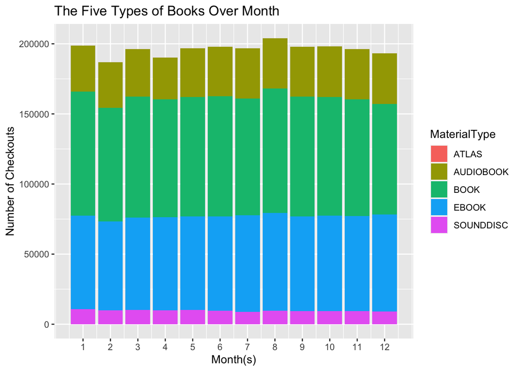

### Second Trends Over Time Chart

The chart shows the trends of checkouts from 2022 to 2023. The chart only contains data for the five values, books, atlas, audiobook, book, ebook, and sounddisc since I already filtered them. The overall number of checkouts in 2022 is 7755642 while the overall number of 2023 is 737020. That is why the slope is downhill. I wanted to represent that chart to show the overall number of checkouts over years. However, the data for 2023 is not enough compared to the data from 2022. That is why the chart is a steeply reduced chart.

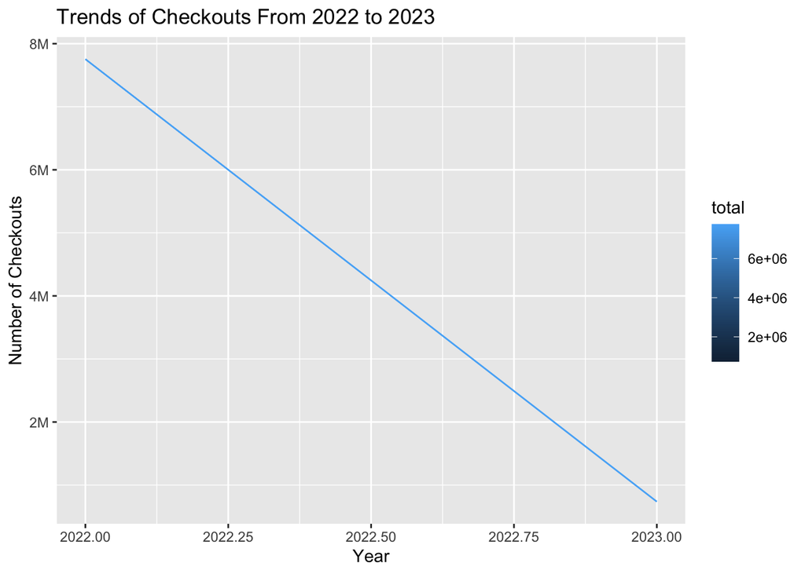

### Your Choice

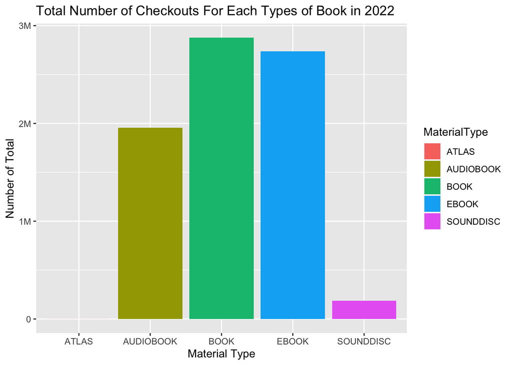